# Test de Student

S. Jaubert

07/10/2020

**Référence : l’excellent site d’Antoine Massé https://sites.google.com/site/rgraphiques**

## Test de Student

Le [test de Student](https://fr.wikipedia.org/wiki/William_Gosset) permet de comparer deux moyennes d’échantillons afin de voir si ceux-ci sont vraisemblablement issues de la même population (hypothèse nulle $H_{0}$) ou, au contraire, significativement différentes.

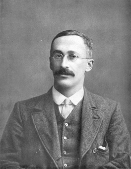

william Sealy Gosset en 1908

Plus simplement : ce test donne la probabilité qu’une différence observée soit due au hasard. [Source](https://sites.google.com/site/rgraphiques/4--stat/comparaison-de-moyennes-avec-r/test-de-student)

Cette probabilité s’appelle la p-value.

### Quelques rappels théoriques

On peut lire ( https://fr.wikipedia.org/wiki/Loi_de_Student )

Soit $Z$ une variable aléatoire de loi normale centrée et réduite et soit $U$ une variable indépendante de $Z$ et distribuée suivant la loi du $χ2$ à $k$ degrés de liberté. Par définition, la variable :

$$T=\frac {Z}{\sqrt {\frac{U}{k}}}$$
suit une loi de Student à $k$ degrés de liberté.

A présent soit $\bar{X}$ la variable aléatoire moyenne d’un échantillon de taille $n$ issu d’une population de moyenne $\mu$ et d’écart-type $\sigma$

Nous savons que :

$$\bar{X}\hookrightarrow \mathcal{N}(\mu;\frac{\sigma}{\sqrt{n}})$$

avec $\mu$ et $\sigma$ inconnus

Or nous savons qu’un estimateur sans biais de $\sigma²$ est :
$$S_{n-1}^{2}=\frac{n}{n-1}S_{n}^{2}$$

où
$$S_{n}^{2}=\frac{1}{n}\sum_{i=1}^{n}(X_{1}-\bar{X})^{2}$$
et donc
$$U=\frac{nS_{n}^{2}}{\sigma²}=\frac{(n-1)S_{n-1}^{2}}{\sigma²}$$
suit une loi du $\chi^{2}$ à $n-1$ ddl

De plus on peut écrire : $\frac{U}{n-1}=\frac{S_{n-1}^{2}}{\sigma²}$

Par conséquent nous pouvons écrire :

$$\frac{\bar{X}-\mu}{\frac{\sigma}{\sqrt{n}}} =\frac{\bar{X}-\mu}{\frac{S_{n-1}}{\sqrt{n}}}$$
$$=\frac{\bar{X}-\mu}{\frac{S_{n-1}}{\sqrt{n}}}$$
$$=\frac{(\bar{X}-\mu) \;\sigma}{\frac{\sigma}{\sqrt{n}} S_{n-1}} =\frac{Z\sigma}{S_{n-1}}$$
$$=\frac{Z}{\frac{S_{n-1}}{\sigma}}=\frac{Z}{\sqrt{\frac{U}{n-1}}}$$

Par conséquent $\frac{\bar{X}-\mu}{\frac{\sigma}{\sqrt{n}}}$ suit bien la loi de Student à $(n-1)$ ddl

## **Analyser les résultats d’un test de Student :**

p-value < 0.05 - différence significative avec une probabilité de 95%

p-value < 0.01 - différence significative avec une probabilité de 99%

p-value < 0.001 - différence significative avec une probabilité de 99,9%

```r
# Comparaison de x et y
x = c(1,3,2,3,2,5,3,4,2,4,4)
y = c(3,2,8,8,3,2,3,5,6,7,5)
resultat<-t.test(x,y)
```

```r
#Récupérer la p-value : probabilité que les deux échantillons soient d'une même population

resultat$p.value
```

```
## [1] 0.04169425
```

```r
#Afficher le nombre de degré de liberté (pour calcul du test manuellement),
#de l'intervalle de confiance ? 95% par défaut,
#le résultat t du test :

resultat$parameter
```

```
##       df
## 15.00555
```

```r
resultat$conf.int
```

```
## [1] -3.3805058 -0.0740397
## attr(,"conf.level")
## [1] 0.95
```

```r
resultat$statistic
```

```
##         t
## -2.226834
```

*Exemple*

```r
taille_pop <- c(rnorm(19000,175,10),rnorm(21000,168,6))
ech_h <- c(taille_pop[13:112])
ech_f <- c(taille_pop[22013:22112])
sx_pop = c(rep("M",19000), rep("F",21000))
ordre = 1:length(taille_pop)
ordre = sample(ordre)
taille_pop = taille_pop[ordre]
sx_pop = sx_pop[ordre]

ech_t1 <- c(taille_pop[13:112])
ech_t2 <- c(taille_pop[1013:1112])
# La population de Périgueux a été recensée et la taille des individus notée.
# On compare deux échantillons d'individus : ech_t1 et ech_t2
# On compare aussi deux échantillons d'hommes et de femmes : ech_h et ech_f
```

1- Faire un test de student afin de déterminer si les échantillons ech_t1 et ech_t2 appartiennent probablement à des populations différentes.

```r
resultat = t.test(ech_t1, ech_t2, var.equal=TRUE)
resultat$p.value
```

```
## [1] 0.36382
```

```r
# Les individus viennent de la même population : celle de Périgueux
```

2- Faire un test de student afin de déterminer si les échantillons ech_h et ech_f appartiennent probablement à des populations différentes

```r
resultat = t.test(ech_h, ech_f, var.equal=TRUE)
resultat$p.value
```

```
## [1] 1.954806e-13
```

```r
# Il y a une différence significative entre les hommes et les femmes de Périgueux
```

3- Tracer un histogramme de la taille des habitants de Périgueux (taille_pop)

```r
# MOYENNE MOBILE PAR ITERATION
meanbp = function(vector) {
    #Methode cf. Mosteller et Tukey, 1977 : permet de pondérer les valeurs en fonctions de la distance qui les sépare de la médiane
    if (length(vector) >2) {
        EIQ = abs(quantile(vector,probs=0.75)-quantile(vector,probs=0.25))
         Z = (vector - median(vector))/(3*EIQ)
        for (i in c(1:length(vector))) {
           if (abs(Z[i])>1) {Z[i]=1}
        }
        w = (1-Z^2)^2
        moyenne = sum(vector*w)/sum(w)
        #Methode complément A.M. : permet de pondérer les valeurs en fonctions de la distance qui les sépare de la moyenne calculée précédement (1000 cycles maximum)
        for (j in c(1:1000)) {
            moyenne_old = moyenne
                d = abs(vector-moyenne)
                EIQ = (quantile(d,probs=0.75))+(quantile(d,probs=0.25))
                  Z = (vector - moyenne)/(3*EIQ)
                for (i in c(1:length(vector))) {
                   if (abs(Z[i])>1) {Z[i]=1}
                }
                w = (1-Z^2)^2
                moyenne = sum(vector*w)/sum(w)
            variation = sd(vector)/(moyenne_old-moyenne)
            if (moyenne ==moyenne_old) { break } # si moyenne ne bouge plus
            if (variation > 1000) { break} # si le signal sur bruit est élevé
        }
    }
    else {moyenne = mean(vector)}
    return(moyenne)
}
```

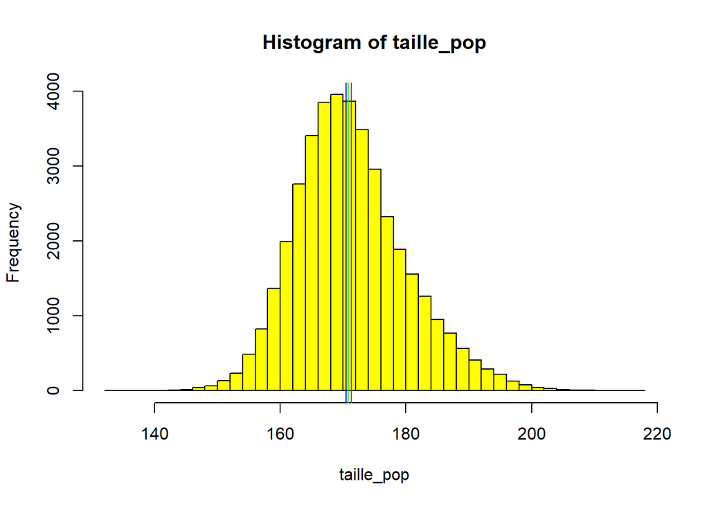

```r
hist(taille_pop,col="yellow",breaks=40)
abline(v=mean(taille_pop),col="red")
abline(v=median(taille_pop),col="blue")
# Aller copier-coller la fonction meanbp
abline(v=meanbp(taille_pop),col="green")
```